# Project Report: Global Happiness Analysis

# Introduction

## Goal of the Analysis

In this project we investigated what are the main drivers of happiness across countries and regions. We hypothesized that the following factors may have a significant effect on nation's happiness level:

- Economic well being,
- Education,
- Internet propogation,
- Life expectency.

We used these variables to analyse their relationship with the overall happiness level across different countries.

## Peer Review & Contributions

Our group divided the responsibilites to better handle the scale of the project.

- Aslbek. Data Processing. Contribution: 20%  
  True Data Miner! Aslbek manually parsed the csv files and excel sheets. He managed to find problems with the raw datasets and suggested insightful ideas to solve them. For example, he found out that the given datasets had mismatching labels for countries, he solved this issue with dictionaries and found external sources to fill in the NaN values in the data frames.
- Kassymkhan. Prompt Engineering. Contribution: 20%  
  Kassymkhan used multiple AI-models and prompt engineering techniques to generate insightful insights for our analysis. He also helped with writing the main body of the final report.
- Yernur. Data Plotting. Contribution: 30%  
  The only one who cared about frontend elements in the project. He made sure that the plots were clear and readable. For example, he suggested to label few countries in the scatter plot and moved the data analysis even beyond.
- Olzhas. Data Analysis. Contribution: 30%  
  The sudo team lead. Olzhas led the data analysis process because only he had the full view: he knew how to analyse the data and pick relevant tools. For example, he suggested an innovative way to analyse the data - via logarithmically scaled linear regression which had surprisingly low MSE value.

## Structure of the Analysis

$\downarrow$ Data Processing: Loading the data $ \rightarrow $ Cleaning the data $\rightarrow $ Merging the datasets  
$\downarrow$ Data Visualization: Scatter plot $ \rightarrow $ Linear regression models $ \rightarrow $ Cluster visualizations  
$\downarrow$ Data Analysis: Main statistics $ \rightarrow $ Analysis & Interpretation $ \rightarrow $ Synthesis  
Conclusion

# Data Processing

In this section, our primary goal was to retain as much data as possible because it would make our analysis more objective.

Structure of the data processing:  
$ \downarrow $ We first loaded the data and focused only on Year 2019, to keep our analysis sharp.  
$ \downarrow $ Then we normalized the data by standartizing the labels in the datasets.  
$ \downarrow $ After this we cleaned the data. We filled in some of the missing values using relavant sources.  
$ \downarrow $ For the "Education expenditure" column, we used KNN-imputing algorithm to extrapolate and fill the missing data values.  
Finally, we merged all the datasets. We successfully managed to keep all the 156 rows in the final dataframe.

```python
# General
import numpy as np
import pandas as pd
import matplotlib.pyplot as plt
import seaborn as sns

# We used KNN Imputing to extrapolate education expenditure
from sklearn.impute import KNNImputer

# Analysis tools
from sklearn.linear_model import LinearRegression
from sklearn.model_selection import train_test_split

# Assessing the accuracy of different models
from sklearn.metrics import mean_squared_error, r2_score

import math

# Polynomial regression for assessing different types of fittings
from sklearn.preprocessing import PolynomialFeatures
from sklearn.pipeline import make_pipeline

# Clusters to group similar coutntries
from sklearn.preprocessing import StandardScaler
from sklearn.cluster import KMeans

# Dashboard
import plotly.express as px
import plotly.graph_objects as go
from ipywidgets import interact, widgets
from IPython.display import display
```

## Loading the data

The primary sources of data is loaded through the relative path `./data/raw/`.  
We will mainly focus on Happiness level dataset (further we will refer to it as `hap`).  
Note that `hap` has 156 rows, which we will try to keep as much as possible.

```python
# ================================
# Happiness Dataset (further we will refer to it as "hap")
# ================================
hap_raw = pd.read_csv("./data/raw/happiness.csv")    # Load the raw dataset

hap = hap_raw.rename(columns={                       # Rename columns to match other data sets for future merging
    "Country or region": "Country",
    "Score": "Happiness score",
})

hap["Year"] = 2019                                   # We are limiting our scope to Year 2019
hap = hap.drop(columns=[                             # Drop Irrelevant columns
    "Year",                                          # We consider only Year 2019, therefore we don't need other years
    "Overall rank",                                  # We don't need ranking column, because we will do it on our own
    "GDP per capita",                                # We will use another source for GDP per capita
    "Healthy life expectancy"])                      # We will use another source for Health life expectancy

print("Happiness data (hap):")
hap
```

```
Happiness data (hap):
```

|  | Country | Happiness score | Social support | Freedom to make life choices | Generosity | Perceptions of corruption |
| --- | --- | --- | --- | --- | --- | --- |
| 0 | Finland | 7.769 | 1.587 | 0.596 | 0.153 | 0.393 |
| 1 | Denmark | 7.600 | 1.573 | 0.592 | 0.252 | 0.410 |
| 2 | Norway | 7.554 | 1.582 | 0.603 | 0.271 | 0.341 |
| 3 | Iceland | 7.494 | 1.624 | 0.591 | 0.354 | 0.118 |
| 4 | Netherlands | 7.488 | 1.522 | 0.557 | 0.322 | 0.298 |
| ... | ... | ... | ... | ... | ... | ... |
| 151 | Rwanda | 3.334 | 0.711 | 0.555 | 0.217 | 0.411 |
| 152 | Tanzania | 3.231 | 0.885 | 0.417 | 0.276 | 0.147 |
| 153 | Afghanistan | 3.203 | 0.517 | 0.000 | 0.158 | 0.025 |
| 154 | Central African Republic | 3.083 | 0.000 | 0.225 | 0.235 | 0.035 |
| 155 | South Sudan | 2.853 | 0.575 | 0.010 | 0.202 | 0.091 |

156 rows × 6 columns

```python
# ================================
# GDP per capita (further we will refer to it as "gdp")
# ================================
gdp_raw = pd.read_excel("./data/raw/gdp.xls", skiprows=3)    # Load the raw dataset

gdp = gdp_raw[["Country Name", "2019"]]                      # We are limiting our scope to Year 2019

gdp = gdp.rename(columns={                                   # Rename the columns
    "Country Name": "Country",
    "2019": "GDP per capita"
})

print("GDP per capita (gdp):")
gdp
```

```
GDP per capita (gdp):
```

|  | Country | GDP per capita |
| --- | --- | --- |
| 0 | Aruba | 31096.205074 |
| 1 | Africa Eastern and Southern | 1493.817938 |
| 2 | Afghanistan | 496.602504 |
| 3 | Africa Western and Central | 1798.340685 |
| 4 | Angola | 2189.855714 |
| ... | ... | ... |
| 261 | Kosovo | 4415.997161 |
| 262 | Yemen, Rep. | NaN |
| 263 | South Africa | 6533.711210 |
| 264 | Zambia | 1258.986198 |
| 265 | Zimbabwe | 1683.913136 |

266 rows × 2 columns

```python
# ================================
# Education Expenditure (further we will refer to it as "edu")
# ================================
edu_raw = pd.read_excel("./data/raw/education.xls", skiprows=3)      # Load the raw dataset

edu = edu_raw[["Country Name", "2019"]]                              # We are limiting our scope to Year 2019

edu = edu.rename(columns={                                           # Rename the columns
    "Country Name": "Country",
    "2019": "Education expenditure"
})

print("Education expenditure (edu):")
edu
```

```
Education expenditure (edu):
```

|  | Country | Education expenditure |
| --- | --- | --- |
| 0 | Aruba | 4.435037 |
| 1 | Africa Eastern and Southern | 4.511410 |
| 2 | Afghanistan | NaN |
| 3 | Africa Western and Central | 3.047399 |
| 4 | Angola | 2.073064 |
| ... | ... | ... |
| 261 | Kosovo | NaN |
| 262 | Yemen, Rep. | NaN |
| 263 | South Africa | 5.911580 |
| 264 | Zambia | 4.418240 |
| 265 | Zimbabwe | NaN |

266 rows × 2 columns

```python
# ================================
# Life Expectancy Rates (further we will refer to it as "exp")
# ================================
exp_raw = pd.read_excel("./data/raw/LifeExpectancy.xls", skiprows=3)  # Load the raw dataset

exp = exp_raw[['Country Name', '2019']]                               # We are limiting our scope to Year 2019

exp = exp.rename(columns={                                            # Rename the columns
    "Country Name": "Country",
    "2019": "Life expectancy"
})

print("Life expectancy (exp):")
exp
```

```
Life expectancy (exp):
```

|  | Country | Life expectancy |
| --- | --- | --- |
| 0 | Aruba | 76.019000 |
| 1 | Africa Eastern and Southern | 63.857261 |
| 2 | Afghanistan | 62.941000 |
| 3 | Africa Western and Central | 57.149847 |
| 4 | Angola | 63.051000 |
| ... | ... | ... |
| 261 | Kosovo | 77.249000 |
| 262 | Yemen, Rep. | 66.567000 |
| 263 | South Africa | 66.071000 |
| 264 | Zambia | 62.914000 |
| 265 | Zimbabwe | 61.060000 |

266 rows × 2 columns

```python
# ================================
# Internet Penetration Rates (further we will refer to it as "net")
# ================================
net_raw = pd.read_excel("./data/raw/InternetRates.xls", skiprows=3)     # Load the raw dataset
net = net_raw[['Country Name', '2019']]                                 # We are limiting our scope to Year 2019

net = net.rename(columns={                                              # Rename the columns
    "Country Name": "Country",
    "2019": "Internet Users(% of Pop)"
})

print("Internet Users(% of Pop) (net):")
net
```

```
Internet Users(% of Pop) (net):
```

|  | Country | Internet Users(% of Pop) |
| --- | --- | --- |
| 0 | Aruba | NaN |
| 1 | Africa Eastern and Southern | 22.4000 |
| 2 | Afghanistan | 17.6000 |
| 3 | Africa Western and Central | 28.7000 |
| 4 | Angola | 32.1294 |
| ... | ... | ... |
| 261 | Kosovo | NaN |
| 262 | Yemen, Rep. | NaN |
| 263 | South Africa | 69.6969 |
| 264 | Zambia | 18.7000 |
| 265 | Zimbabwe | 26.5883 |

266 rows × 2 columns

### Problem: Mismatching labels

We noticed that there are mismatching labels for countries and regions.  
For example, in the dataset `hap` the country Russia is labeled as "Russia",  
but in the dataset `gdp` it is labeled as "Russian Federation".

This is a problem because if we left-merged all the data right away, we would have a lot of 'NaN' values or duplicates.  
(credits for this observation and for its solution: Aslbek).

We need to label countries with consistent naming.  
To do this, we chose labels in the dataset `gdp` as the base labels, then we renamed mismathcing countries in other datasets.

### Solution: Label correction

To resolve this problem, we found all the countries that have different labels.  
To do this, we used type 'set' to easily find such differences.

This way, we find all the labels that need to be changed.

```python
# ================================
# Identifying the mismatches
# ================================
print("hap vs gdp:")
print(set(hap['Country']) - set(gdp['Country']))     # Mismatches between hap vs. gdp
print("\n\n")


print("hap vs edu:")
print(set(hap['Country']) - set(edu['Country']))     # Mismatches between hap vs. edu
print("\n\n")


print("hap vs exp:")
print(set(hap['Country']) - set(exp['Country']))     # Mismatches between hap vs. exp
print("\n\n")


print("hap vs net:")
print(set(hap['Country']) - set(net['Country']))     # Mismatches between hap vs. net
print("\n\n")
```

```
hap vs gdp:
{'Palestinian Territories', 'Czech Republic', 'Kyrgyzstan', 'Venezuela', 'Somalia', 'Russia', 'Hong Kong', 'Slovakia', 'Congo (Brazzaville)', 'Vietnam', 'Northern Cyprus', 'Syria', 'Laos', 'Congo (Kinshasa)', 'Ivory Coast', 'Gambia', 'Egypt', 'Swaziland', 'Yemen', 'South Korea', 'Trinidad & Tobago',…



hap vs edu:
{'Palestinian Territories', 'Czech Republic', 'Kyrgyzstan', 'Venezuela', 'Somalia', 'Russia', 'Hong Kong', 'Slovakia', 'Congo (Brazzaville)', 'Vietnam', 'Northern Cyprus', 'Syria', 'Laos', 'Congo (Kinshasa)', 'Ivory Coast', 'Gambia', 'Egypt', 'Swaziland', 'Yemen', 'South Korea', 'Trinidad & Tobago',…



hap vs exp:
{'Palestinian Territories', 'Czech Republic', 'Kyrgyzstan', 'Venezuela', 'Somalia', 'Russia', 'Hong Kong', 'Slovakia', 'Congo (Brazzaville)', 'Vietnam', 'Northern Cyprus', 'Syria', 'Laos', 'Congo (Kinshasa)', 'Ivory Coast', 'Gambia', 'Egypt', 'Swaziland', 'Yemen', 'South Korea', 'Trinidad & Tobago',…



hap vs net:
{'Palestinian Territories', 'Czech Republic', 'Kyrgyzstan', 'Venezuela', 'Somalia', 'Russia', 'Hong Kong', 'Slovakia', 'Congo (Brazzaville)', 'Vietnam', 'Northern Cyprus', 'Syria', 'Laos', 'Congo (Kinshasa)', 'Ivory Coast', 'Gambia', 'Egypt', 'Swaziland', 'Yemen', 'South Korea', 'Trinidad & Tobago',…
```

Now that we have the mismatching labels, we can create a `name_corrections` dictionary (see below). `name_corrections` has 'inconsistent' labels as keys and 'standartized' labels as values.

```python
# ================================
# Correcting the labels
# ================================

# Define a dictionary with keys as "inconsistent" labels and values as "more universal" labels:
# e.g. 'Kyrgyzstan': 'Kyrgyz Republic',

name_corrections = {
    'Kyrgyzstan': 'Kyrgyz Republic',
	'Congo (Brazzaville)': 'Congo, Rep.',
	'Congo (Kinshasa)': 'Congo, Dem. Rep.',
	'Czech Republic': 'Czechia',
	'Egypt': 'Egypt, Arab Rep.',
	'Gambia': 'Gambia, The',
	'Hong Kong': 'Hong Kong SAR, China',
	'Iran': 'Iran, Islamic Rep.',
	'Northern Cyprus': 'Northern Mariana Islands',
	'Palestinian Territories': 'West Bank and Gaza',
	'Russia': 'Russian Federation',
	'Slovakia': 'Slovak Republic',
	'Somalia': 'Somalia, Fed. Rep.',
	'South Korea': 'Korea, Rep.',
	'Syria': 'Syrian Arab Republic',
	'Trinidad & Tobago': 'Trinidad and Tobago',
	'Turkey': 'Turkiye',
	'Venezuela': 'Venezuela, RB',
	'Vietnam': 'Viet Nam',
	'Yemen': 'Yemen, Rep.',
	'Ivory Coast': 'Cote d\'Ivoire',
	'Laos': 'Lao PDR',
	'Swaziland': 'Eswatini',
}

# We change labels of the datasets using the name_corrections dictionary:
# e.g. 'Kyrgyzstan' --> 'Kyrgyz Republic'
hap['Country'] = hap['Country'].replace(name_corrections)
edu['Country'] = edu['Country'].replace(name_corrections)
exp['Country'] = exp['Country'].replace(name_corrections)
```

Now that we have consistent labels, we can left-merge all the datasets.

> Note: the new data set `df_raw` (see below) has exactly 156 rows, which means that no country was left out.  
> However, we called this dataset 'raw' because it still has missing values, which will be addressed in the next subsection.

```python
# ================================
# Left merging. The new Dataframe (further we will refer to it as 'df_raw')
# ================================
df_raw = (
    hap
    .merge(gdp, on=["Country"], how="left")
    .merge(edu, on=["Country"], how="left")
    .merge(exp, on=["Country"], how="left")
    .merge(net, on=["Country"], how="left")
)

print("Raw merged main data frame:")
df_raw
```

```
Raw merged main data frame:
```

|  | Country | Happiness score | Social support | Freedom to make life choices | Generosity | Perceptions of corruption | GDP per capita | Education expenditure | Life expectancy | Internet Users(% of Pop) |
| --- | --- | --- | --- | --- | --- | --- | --- | --- | --- | --- |
| 0 | Finland | 7.769 | 1.587 | 0.596 | 0.153 | 0.393 | 48358.180777 | 6.453000 | 81.982927 | 89.60740 |
| 1 | Denmark | 7.600 | 1.573 | 0.592 | 0.252 | 0.410 | 59404.266325 | 7.275880 | 81.451220 | 98.04640 |
| 2 | Norway | 7.554 | 1.582 | 0.603 | 0.271 | 0.341 | 76430.588947 | 7.864560 | 82.958537 | 98.00000 |
| 3 | Iceland | 7.494 | 1.624 | 0.591 | 0.354 | 0.118 | 68452.236223 | 7.601300 | 83.163415 | 99.50490 |
| 4 | Netherlands | 7.488 | 1.522 | 0.557 | 0.322 | 0.298 | 53554.900749 | 5.055940 | 82.112195 | 93.28860 |
| ... | ... | ... | ... | ... | ... | ... | ... | ... | ... | ... |
| 151 | Rwanda | 3.334 | 0.711 | 0.555 | 0.217 | 0.411 | 810.051412 | 3.238212 | 66.691000 | 21.35800 |
| 152 | Tanzania | 3.231 | 0.885 | 0.417 | 0.276 | 0.147 | 1063.322510 | 3.596836 | 66.007000 | 16.59090 |
| 153 | Afghanistan | 3.203 | 0.517 | 0.000 | 0.158 | 0.025 | 496.602504 | NaN | 62.941000 | 17.60000 |
| 154 | Central African Republic | 3.083 | 0.000 | 0.225 | 0.235 | 0.035 | 449.228468 | 1.767921 | 31.530000 | 7.50916 |
| 155 | South Sudan | 2.853 | 0.575 | 0.010 | 0.202 | 0.091 | NaN | NaN | 58.129000 | 6.70000 |

156 rows × 10 columns

## Data Cleaning

In this subsection, we clean the main dataframe `df_raw`. We used three strategies to address the missing values while trying to keep bias low:

1. We used historical imputation
2. We used external data
3. KNN imputation

In order to clean the data we first printed how many missing values there are.

```python
# ================================
# Finding the number of missing values
# ================================
df_raw.isna().sum()
```

```
Country                          0
Happiness score                  0
Social support                   0
Freedom to make life choices     0
Generosity                       0
Perceptions of corruption        0
GDP per capita                   4
Education expenditure           25
Life expectancy                  1
Internet Users(% of Pop)        11
dtype: int64
```

### Historical imputation

We looked back at the original datasets, and filled in some missing values with values from previous years.  
For example, the country South Sudan had a missing "GDP per capita" field for 2019. We filled it in with "GDP per capita" field from 2015.  
To reduce the error, we filled only those missing fields that had reasonably recent available 'filler' fields.  
Historical imputation ensures that all the data were consistent and used the same metrics.

```python
# ================================
# Filling in the missing GDP per capita data with recent years
# ================================
gdp_filling = {
    'Venezuela, RB': 15943.61,      # from 2014
    'Yemen, Rep.': 633.89,          # from 2018
    'South Sudan': 1080.15,         # from 2015
    'Taiwan': 36000                 # IMF estimate
}

for k, v in gdp_filling.items():
    df_raw.loc[df_raw['Country'] == k, 'GDP per capita'] = v
```

### Using external data sources

To fill in other missing values we used external data sources.  
To reduce bias, we used data from the same sources.

```python
# ================================
# Filling in the missing GDP per capita data
# ================================
exp_filling = {
    # https://taiwantoday.tw/Society/Top-News/182736/Average-life-expectancy-hits-80.86-in-Taiwan
    "Taiwan": 80.86,
}

for k, v in exp_filling.items():
    df_raw.loc[df_raw["Country"]== k, "Life expectancy"] = v


# ================================
# Filling in the missing Internet Propogation data
# ================================
net_filling={
    # https://report.twnic.tw/2019/assets/download/TWNIC_TaiwanInternetReport_2019_EN.pdf
    "Taiwan":85.6,
    "Kosovo":89.443,                #from 2018
    "Northern Mariana Islands":66,  # (Est.)
    "Libya":87.575,                 #from 2020
    "Tajikistan":27.544,            #from 2020
    "Turkmenistan":21.251,          #from 2017
    "Uganda":7.4,                   #from 2020
    "Yemen, Rep.":13.815,           #from 2020
    "Congo, Rep.":24.821,           #from 2020
    "Somalia, Fed. Rep.":15.024,    #from 2020
    "Venezuela, RB":61.6,           #from 2017
}

for k, v in net_filling.items():
    df_raw.loc[df_raw['Country'] == k, 'Internet Users(% of Pop)'] = v
```

### KNN imputation algorithm

A big problem for us was the "Education expenditure" fields, because it was difficult to find sources that would measure the education expenditure in the same metrics.  
Since the number of these missing fields was significant, we decided to not to dropping but to extrapolate them.  
In order to do so, we used K-Nearest-Neighborhood imputing algorithm.

The algorithm finds the `K` nearest neighbors that are most similar to the country with missing data based on other factors (GDP, Life Expectancy, etc).  
It then "predicts" the missing "Education expenditure" values, by taking a weighted average of these nearest neighbors. (weights were chosen as 'closeness')

This allowed us to make reasonably good guesses on a lot of missing values.

```python
# ================================
# KNN Model extrapolation
# ================================
features = df_raw.drop(columns=['Country'])                         # We drop the string column 'Country'

imputer = KNNImputer(n_neighbors=5, weights='distance')             # Look at the 5 closest neighbors.
                                                                    # Note: we define weights as 'distance'
imputed_arr = imputer.fit_transform(features)                       # This line fills in the missing numbers but returns an array with no column names

imputed = pd.DataFrame(imputed_arr, columns=features.columns)       # We convert the array back to a dataframe to retrieve the column names

imputed['Country'] = df_raw['Country']                              # This line is here to make sure every row has an appropriate country field

df_raw['Education expenditure'] = imputed['Education expenditure']  # We take the newly filled 'Education expenditure' column and put it back into our main dataframe
```

## Final dataframe

We sorted the obtained final dataframe by "Happiness score" column in descending order. It makes the further analysis easier. Forexample, it sets us up for printing the top and bottom 10 countries. We also called it `df` as it will be our main dataframe that we will manipulate the most with. At the end we made a final check for any missing values, and indeed we managed to keep all the rows, however we will recall that our attempt for comprehensiveness will might've costed us some degree of error.

```python
# ================================
# Sorting the final dataframe (further we will refer to it as "df")
# ================================
df = df_raw.sort_values(by="Happiness score", ascending=False)

print("Merged main dataframe (ranked by happiness score):")
df
```

```
Merged main dataframe (ranked by happiness score):
```

|  | Country | Happiness score | Social support | Freedom to make life choices | Generosity | Perceptions of corruption | GDP per capita | Education expenditure | Life expectancy | Internet Users(% of Pop) |
| --- | --- | --- | --- | --- | --- | --- | --- | --- | --- | --- |
| 0 | Finland | 7.769 | 1.587 | 0.596 | 0.153 | 0.393 | 48358.180777 | 6.453000 | 81.982927 | 89.60740 |
| 1 | Denmark | 7.600 | 1.573 | 0.592 | 0.252 | 0.410 | 59404.266325 | 7.275880 | 81.451220 | 98.04640 |
| 2 | Norway | 7.554 | 1.582 | 0.603 | 0.271 | 0.341 | 76430.588947 | 7.864560 | 82.958537 | 98.00000 |
| 3 | Iceland | 7.494 | 1.624 | 0.591 | 0.354 | 0.118 | 68452.236223 | 7.601300 | 83.163415 | 99.50490 |
| 4 | Netherlands | 7.488 | 1.522 | 0.557 | 0.322 | 0.298 | 53554.900749 | 5.055940 | 82.112195 | 93.28860 |
| ... | ... | ... | ... | ... | ... | ... | ... | ... | ... | ... |
| 151 | Rwanda | 3.334 | 0.711 | 0.555 | 0.217 | 0.411 | 810.051412 | 3.238212 | 66.691000 | 21.35800 |
| 152 | Tanzania | 3.231 | 0.885 | 0.417 | 0.276 | 0.147 | 1063.322510 | 3.596836 | 66.007000 | 16.59090 |
| 153 | Afghanistan | 3.203 | 0.517 | 0.000 | 0.158 | 0.025 | 496.602504 | 3.233339 | 62.941000 | 17.60000 |
| 154 | Central African Republic | 3.083 | 0.000 | 0.225 | 0.235 | 0.035 | 449.228468 | 1.767921 | 31.530000 | 7.50916 |
| 155 | South Sudan | 2.853 | 0.575 | 0.010 | 0.202 | 0.091 | 1080.150000 | 3.127607 | 58.129000 | 6.70000 |

156 rows × 10 columns

```python
# ================================
# Final check for any missing values
# ================================
print("Checking for missing values:")
print(df.isna().sum())
```

```
Checking for missing values:
Country                         0
Happiness score                 0
Social support                  0
Freedom to make life choices    0
Generosity                      0
Perceptions of corruption       0
GDP per capita                  0
Education expenditure           0
Life expectancy                 0
Internet Users(% of Pop)        0
dtype: int64
```

# Data Visualization

Now that our data is clean, we move to the next section. We explore the main dataframe visually to idenify any patterns, outliers and evaluating the significance of features.

Structure of the data visualization:  
$ \downarrow $ We will first have a 'high-level' look at the data disribution: we print the general statistics information (such as mean and standard deviation), top 10 and bottom 10 countries.  
$ \downarrow $ Then, we build the correlation matrix to identify which variables move together.  
$ \downarrow $ After this, we model using linear regression and polynomial regression models, we also included logarithmic regression. We evaluate those models using MSE metric.  
$ \downarrow $ We determine which factors are the strongest preictors of the happiness level in a country.  
Finally, we use these models to derive some insights.

## General statistics

First, we look at the raw numbers. We identified the 'happiest' and 'least happy' nations to understand the range of our data.  
We observe the following:

- Global Mean: The average happiness score for the world is 5.41.
- Standard Deviation: The standard deviation is 1.11.

Interpretation:  
This standard deviation indicates a moderate spread in global well-being.  
It means that while the "average" country has a score of 5.4, the majority of the world's nations fall comfortably between 4.3 and 6.5.  
Scores significantly outside this range—such as Finland (>7.5) or South Sudan (<3.0)—represent distinct outliers at the extreme ends of the spectrum.

By examining the tables below, we found the outliers at both ends of the scale:  
The Happiest Countries:

- Finland (7.769)
- Denmark (7.600)
- Norway (7.554)

The Least Happy Countries:

- South Sudan (2.853)
- Central African Republic (3.083)
- Afghanistan (3.203)

```python
# ================================
# Basic statistics
# ================================
print("Basic statistics:")
df.describe()
```

```
Basic statistics:
```

|  | Happiness score | Social support | Freedom to make life choices | Generosity | Perceptions of corruption | GDP per capita | Education expenditure | Life expectancy | Internet Users(% of Pop) |
| --- | --- | --- | --- | --- | --- | --- | --- | --- | --- |
| count | 156.000000 | 156.000000 | 156.000000 | 156.000000 | 156.000000 | 156.000000 | 156.000000 | 156.000000 | 156.000000 |
| mean | 5.407096 | 1.208814 | 0.392571 | 0.184846 | 0.110603 | 15532.793974 | 4.167740 | 72.739753 | 59.804101 |
| std | 1.113120 | 0.299191 | 0.143289 | 0.095254 | 0.094538 | 20869.075137 | 1.533167 | 8.461189 | 28.343718 |
| min | 2.853000 | 0.000000 | 0.000000 | 0.000000 | 0.000000 | 210.236495 | 0.000006 | 31.530000 | 6.100000 |
| 25% | 4.544500 | 1.055750 | 0.308000 | 0.108750 | 0.047000 | 1959.961195 | 3.154773 | 66.719500 | 34.321650 |
| 50% | 5.379500 | 1.271500 | 0.417000 | 0.177500 | 0.085500 | 5971.778670 | 4.202101 | 74.218915 | 68.232300 |
| 75% | 6.184500 | 1.452500 | 0.507250 | 0.248250 | 0.141250 | 19456.742825 | 5.029502 | 78.681707 | 83.342650 |
| max | 7.769000 | 1.624000 | 0.631000 | 0.566000 | 0.453000 | 112696.649060 | 9.322532 | 85.155854 | 99.701500 |

```python
# ================================
# Top 10 Countries by Happiness Score
# ================================
top_10 = df[["Country", "Happiness score"]].head(10)        # we used that df is already sorted
print("Top 10 happy countries:")
top_10
```

```
Top 10 happy countries:
```

|  | Country | Happiness score |
| --- | --- | --- |
| 0 | Finland | 7.769 |
| 1 | Denmark | 7.600 |
| 2 | Norway | 7.554 |
| 3 | Iceland | 7.494 |
| 4 | Netherlands | 7.488 |
| 5 | Switzerland | 7.480 |
| 6 | Sweden | 7.343 |
| 7 | New Zealand | 7.307 |
| 8 | Canada | 7.278 |
| 9 | Austria | 7.246 |

```python
# ================================
# Bottom 10 Countries by Happiness Score
# ================================
bottom_10 = df[["Country", "Happiness score"]].tail(10)       # df is already sorted
print("Bottom 10 happy countires:")
bottom_10
```

```
Bottom 10 happy countires:
```

|  | Country | Happiness score |
| --- | --- | --- |
| 146 | Haiti | 3.597 |
| 147 | Botswana | 3.488 |
| 148 | Syrian Arab Republic | 3.462 |
| 149 | Malawi | 3.410 |
| 150 | Yemen, Rep. | 3.380 |
| 151 | Rwanda | 3.334 |
| 152 | Tanzania | 3.231 |
| 153 | Afghanistan | 3.203 |
| 154 | Central African Republic | 3.083 |
| 155 | South Sudan | 2.853 |

## Correlation Matrix (Heatmap)

In this subsection, we move from *which* countries are happy, but *why* they are happy.  
By computing the correlation coefficients for every pair of features, we can quantify how strongly each factor relates to the "Happiness Score."  
A coefficient of `1.0` indicates a perfect positive relationship, while `0.0` indicates no linear relationship at all.

This helps us with defining anchors for further hypotheses.  
The heatmap below visualize the relationships between all the variables.

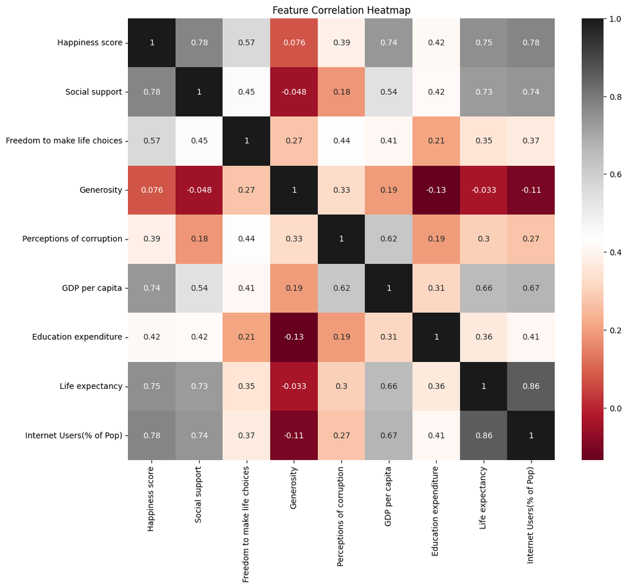

```python
# ================================
# Correlation matrix (Heat map)
# ================================
corr_matrix = df.select_dtypes(include=['number']).corr()   # We select only numeric columns to avoid errors

# ================================
# Visualization
# ================================
plt.figure(figsize=(12,10))
sns.heatmap(corr_matrix, annot=True, cmap='RdGy')
plt.title("Feature Correlation Heatmap")
plt.show()
```

### Selection for Further Analysis

While `Internet Users` and `Life Expectancy` are strong predictors, they often act as proxies for a wealthy economy (high multicollinearity).

For our detailed Single Feature Linear Regression analysis in the next section, we have chosen GDP per capita as our primary independent variable. We selected it because:

1. It is a "hard" statistic (measured in dollars) rather than a subjective survey score.
2. It shows a strong, consistent correlation (0.74) with happiness.
3. It allows us to clearly observe the economic disparities between the "happiest" and "least happy" nations.

## Regression Analysis

### Data Preparation & Scatter Plot

To build our regression models, we first isolate our variables.  
It would be difficult to visualize high dimensional data. Therefore we limited our scope to the following:

- Independent Variable (X): GDP per Capita (The input)
- Dependent Variable (y): Happiness Score (The target)

> Note: We define `X_CONST` and `Y_CONST` as immutable references for this section to ensuring the raw data remains consistent across different models.

First Visualization: We begin by plotting these two variables to see the raw distribution and identifying specific countries of interest.

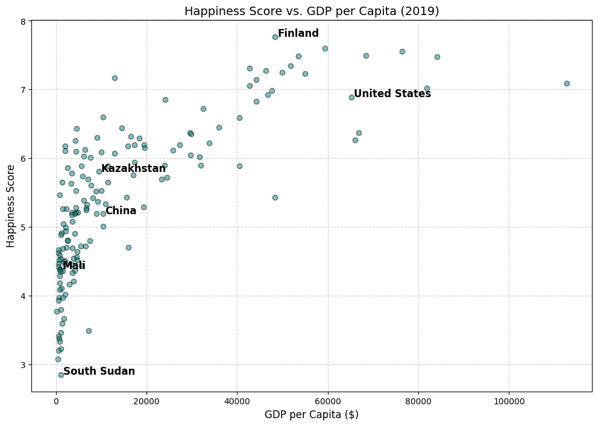

```python
# ==========================================
# Scatter Plot
# ==========================================

# We use UPPERCASE to denote that these should not be modified.
X_CONST = df['GDP per capita']
Y_CONST = df['Happiness score']

# Scatter plot. We will use this setup throught out the visualization part
plt.figure(figsize=(12, 8))
plt.scatter(X_CONST, Y_CONST, alpha=0.5, c='teal', edgecolors='k')

plt.title('Happiness Score vs. GDP per Capita (2019)', fontsize=14)
plt.xlabel('GDP per Capita ($)', fontsize=12)
plt.ylabel('Happiness Score', fontsize=12)
plt.grid(True, linestyle='--', alpha=0.6)



# ==========================================
# Visualization. Labelling a few countries
# ==========================================

countries_to_label = {                                  # Labeling Specific Countries
    'Finland',        # The happiest                    # (credits for labelling key countries to give context to the dots: Yernur)
    'South Sudan',    # The least happy
    'United States',  # High GDP
    'China',          # Large economy
    'Kazakhstan',     # Our home :3
    'Mali'            # Random sample
}

for country in countries_to_label:
    row = df[df['Country'] == country]                   # Filter for the specific country's row

    if not row.empty:
        plt.text(                                        # Add text label at the specific (x, y) coordinates
            x=row['GDP per capita'].iloc[0] + 500,       # Offset slightly to right
            y=row['Happiness score'].iloc[0],
            s=country,
            fontsize=12,
            weight='bold',
            color='black'
        )

plt.show()
```

### Polynomial Regression Analysis

To find the best mathematical fit for our data, we tested four different degrees of polynomial regression:

1. Linear (Degree 1): A straight line.
2. Quadratic (Degree 2): A curve (parabola).
3. Cubic (Degree 3): A more complex curve.
4. Quartic (Degree 4): Highly flexible.

Methodology:

- We split the data into Training (80%) and Testing (20%) sets.
- We calculated the MSE (Mean Squared Error) for each model. Lower MSE indicates a better fit.

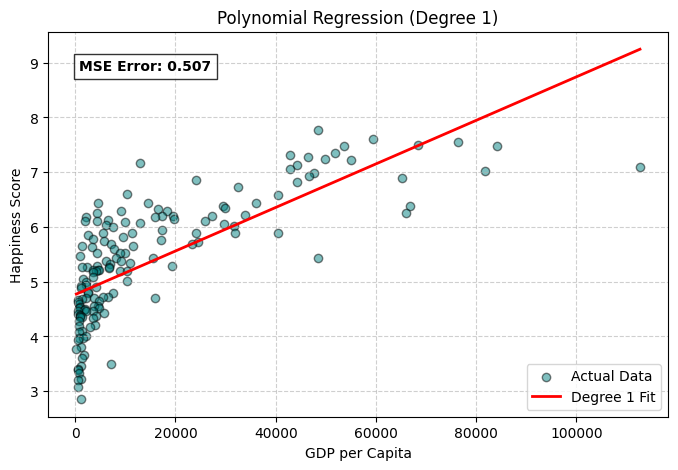

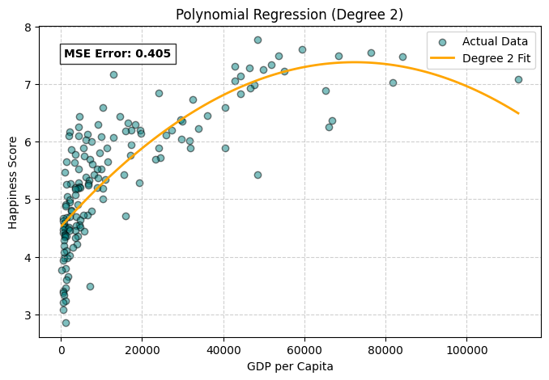

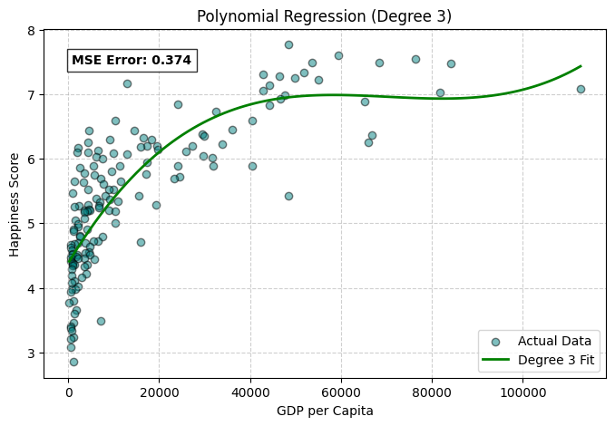

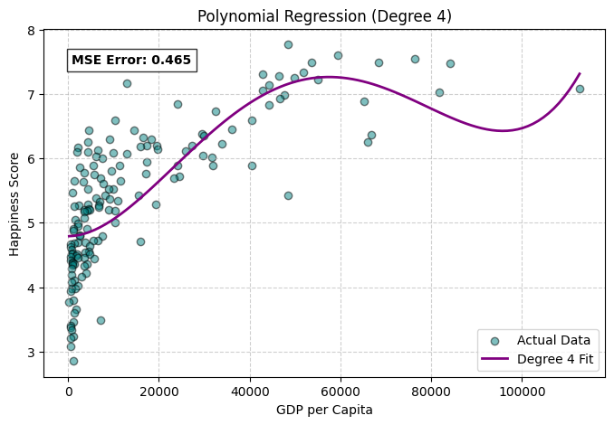

```python
# ==========================================
# Polynomial Regression Loop
# ==========================================

X_reshaped = X_CONST.values.reshape(-1, 1)                  # Prepare the data. Sklearn requires a 2D array (matrix) for X, not a 1D list.

x_train, x_test, y_train, y_test = train_test_split(        # Split data: 80% to train the model, 20% to test it
    X_reshaped, Y_CONST, test_size=0.2, random_state=42
)

x_line = np.linspace(X_CONST.min(), X_CONST.max(), 100).reshape(-1, 1)  # Create a smooth line for plotting the curve (min GDP to max GDP)

degrees = [1, 2, 3, 4]                                       # Configuration for degrees and colors
colors = ['red', 'orange', 'green', 'purple']

for deg, color in zip(degrees, colors):                      # Build & Train Model for each degree
    model = make_pipeline(                                   # Create a pipeline:
        PolynomialFeatures(degree=deg, include_bias=False),  # First create polynomial features --> Then apply linear regression
        LinearRegression()
    )
    model.fit(x_train, y_train)                              # Model fitting

    y_pred_test = model.predict(x_test)                      # Evaluate the models
    mse = mean_squared_error(y_test, y_pred_test)            # Predict on the test set to see how "wrong" the model is (MSE)


    # ==========================================
    # Visualization (still in the for loop)
    # ==========================================
    plt.figure(figsize=(8, 5))

    # Scatter plot
    plt.scatter(X_CONST, Y_CONST, alpha=0.5,  c='teal', edgecolors='k', label='Actual Data')

    # Plot the regression line (prediction)
    y_line_pred = model.predict(x_line)
    plt.plot(x_line, y_line_pred, color=color, linewidth=2, label=f'Degree {deg} Fit')

    # Styling
    plt.title(f'Polynomial Regression (Degree {deg})', fontsize=12)
    plt.xlabel('GDP per Capita')
    plt.ylabel('Happiness Score')
    plt.legend()
    plt.grid(True, linestyle='--', alpha=0.6)

    # Annotate the MSE score on the plot
    plt.text(0.05, 0.90, f"MSE Error: {mse:.3f}",
             transform=plt.gca().transAxes,
             bbox=dict(facecolor='white', alpha=0.8),
             fontsize=10, weight='bold')

    plt.show()
```

## Logarithmic Regression (credits for the hypothesis and implementation: "Olzhas")

### Observation

During our analysis, we noticed that the relationship between GDP and Happiness isn't strictly linear.

- **At low income levels**, a small increase in money leads to a huge jump in happiness.
- **At high income levels**, adding more money has a progressively smaller effect on well-being.

### The Hypothesis

This pattern follows a logarithmic distribution. In economic theory, this is often referred to as **"The Law of Diminishing Returns"** or the **"Catch-up Effect"**. Therefore, we hypothesized that fitting a regression to the *natural logarithm* of GDP would yield a better error score (MSE) than standard linear or polynomial models.

The mathematical formula for this model is:

$$\text{Happiness} = \beta_0 + \beta_1 \cdot \ln(\text{GDP})$$

Where:

- $\beta_0$ is the intercept (the baseline happiness).
- $\beta_1$ is the coefficient that determines the steepness of the curve (how much happiness grows with logarithmic wealth).

### Logarithmic scaling

We hypothesized that the relationship between Wealth and Happiness follows a logarithmic trend.

To test this visually, we plotted the data again but changed the X-axis to a logarithmic scale.

- **Hypothesis:** If the relationship is truly logarithmic, the curved scatter plot should appear as a straight line on the scaled graph.

**Formula for MSE (Log-Scaled Model):** To quantify how well this "straight line" fits the transformed data, we use the Mean Squared Error (MSE).  
In this specific context, the prediction is based on the logarithm of GDP:

$$\text{MSE} = \frac{1}{n} \sum_{i=1}^{n} (y_i - (\beta_0 + \beta_1 \ln(x_i)))^2$$

Where:

- $y_i$ is the actual Happiness Score.
- $\ln(x_i)$ is the natural logarithm of the GDP.
- $\beta_0$ and $\beta_1$ are the intercept and slope found by the linear regression.

```
Logarithmic Regression MSE: 0.3637
Equation: Happiness = 0.63 * ln(GDP) + -0.11
```

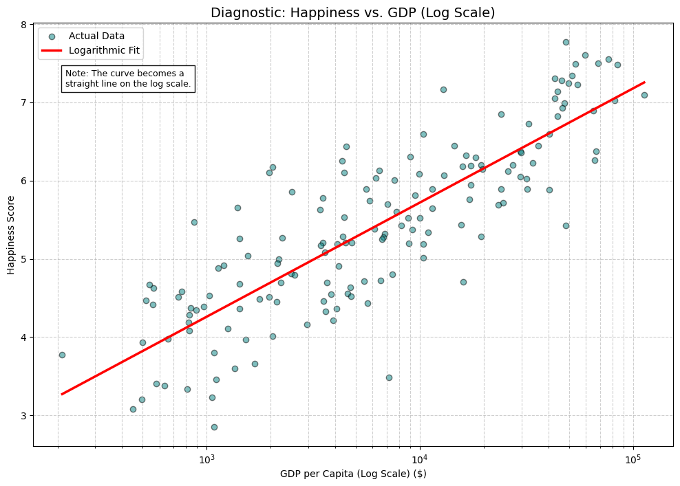

```python
# ==========================================
# Logarithmic Regression
# ==========================================

X = X_CONST.values.reshape(-1, 1)                 # Prepare Data
y = Y_CONST.values

mask = X.flatten() > 0                            # Masking out any possible negative or zero terms
X_clean = X[mask]                                 # This is rather redundant as the datasets don't have non-positive values
y_clean = y[mask]                                 # However this helped us at the development stage, when we worked in parallel with data processing stage

X_log = np.log(X_clean)                           # Log-transforming the x-axis
model = LinearRegression()                        # Building the linear regression model
model.fit(X_log, y_clean)                         # Fitting the model

y_pred = model.predict(X_log)                     # Calculate the evaluation metrics
mse_log = mean_squared_error(y_clean, y_pred)     # We use MSE again


print(f"Logarithmic Regression MSE: {mse_log:.4f}")
print(f"Equation: Happiness = {model.coef_[0]:.2f} * ln(GDP) + {model.intercept_:.2f}")


# ==========================================
# Visualization (Log-Scale)
# ==========================================

# Generate the smooth lines for better visual
x_smooth = np.linspace(X_clean.min(), X_clean.max(), 200).reshape(-1, 1)
y_smooth = model.predict(np.log(x_smooth))

# Scatter Plot
plt.figure(figsize=(12, 8))
plt.scatter(X_CONST, Y_CONST, alpha=0.5, c='teal', edgecolors='k', label='Actual Data')

# Plot the Line (Now possible because we trained the model above!)
plt.plot(x_smooth, y_smooth, color='red', linewidth=2.5, label='Logarithmic Fit')

# Apply Log Scale (This makes the curved line appear straight)
plt.xscale('log')

# Styling
plt.title("Diagnostic: Happiness vs. GDP (Log Scale)", fontsize=14)
plt.xlabel("GDP per Capita (Log Scale) ($)")
plt.ylabel("Happiness Score")
plt.legend()
plt.grid(True, which="both", linestyle='--', alpha=0.6)

# Observation Text
plt.text(0.05, 0.85, "Note: The curve becomes a \nstraight line on the log scale.",
         transform=plt.gca().transAxes,
         fontsize=9,
         bbox=dict(facecolor='white', alpha=0.9))

plt.show()
```

### Reverting the Model

The line indeed looks linear! We revert the scale back to the original format using the derived formula:

$$y = \beta_0 + \beta_1 \ln(x)$$

We calculate the MSE (standard, non-scaled) value again using the standard formula:

$$MSE = \frac{1}{n} \sum_{i=1}^{n} (y_{\text{actual}} - y_{\text{predicted}})^2$$

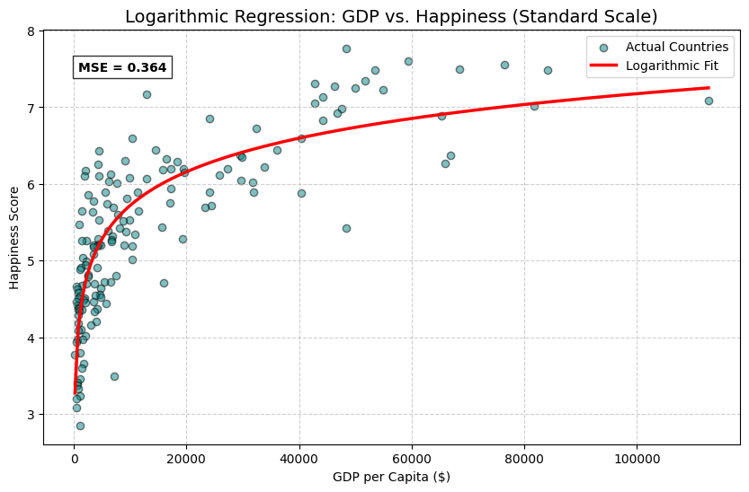

```python
# ==========================================
# Visualization (Standard Scale)
# ==========================================

plt.figure(figsize=(10, 6))

# 1. Scatter plot (Reusing X_clean/y_clean for consistency)
plt.scatter(X_clean, y_clean, alpha=0.5, c='teal', edgecolors='k', label='Actual Countries')

# 2. Plotting the Curve (Reusing x_smooth and y_smooth)
plt.plot(x_smooth, y_smooth, color='red', linewidth=2.5, label='Logarithmic Fit')

# 3. Styling
plt.title("Logarithmic Regression: GDP vs. Happiness (Standard Scale)", fontsize=14)
plt.xlabel("GDP per Capita ($)")
plt.ylabel("Happiness Score")
plt.legend()
plt.grid(True, linestyle='--', alpha=0.6)

# 4. Display MSE
plt.text(0.05, 0.90, f"MSE = {mse_log:.3f}",
         transform=plt.gca().transAxes,
         bbox=dict(facecolor='white', alpha=0.8),
         fontsize=10, weight='bold')

plt.show()
```

## Results Regression Analysis

Based on the charts and regression results, here are the key conclusions derived from the analysis:

### Money Matters, but with Diminishing Returns

The most obvious trend across all charts is a strong positive correlation: wealthier countries generally report higher happiness scores.

- **The "Saturation" Effect:** The relationship is non-linear. The steepest increase in happiness happens when moving from low income to middle income (roughly **US0 to US20,000** GDP per capita).
- **Plateauing:** Beyond roughly **US50,000**, the curve flattens out significantly. This suggests that while basic economic stability is crucial for happiness, extreme wealth yields progressively smaller gains in well-being.

### Model Performance: Linear vs. Polynomial

- **Linear (Degree 1) is Too Simple:** The straight line (**MSE: 0.507**) is the worst fit. It underestimates happiness in poor nations and overestimates it in very rich ones, failing to capture the "curved" reality of the data.
- **Degree 2 & 3 are the "Sweet Spot":** The quadratic (**Degree 2, MSE: 0.405**) and cubic (**Degree 3, MSE: 0.374**) models fit the data much better, effectively capturing the rapid rise and subsequent leveling off.
- **Degree 4 is Overfitting:** The Degree 4 model (**MSE: 0.465**) actually performs *worse* than Degree 3. As seen in the charts, the curve hooks upwards aggressively at the far right. This is a classic case of the model "hallucinating" a trend based on a few outliers rather than capturing a real economic rule.

### Variance Remains (Money Isn't Everything)

- Even with the best-fitting line, there is significant "scatter" or variance. For example, at the **US40,000 GDP** mark, happiness scores range widely between roughly **5.5** and **7.5**.
- This proves that while GDP is a massive predictor, it is not the *only* factor. Variables like social support, freedom, and health likely account for the vertical distance between a dot and the regression line.

## Feature Significance Analysis (Standardized Regression)

### Introduction

While the correlation matrix tells us how each variable relates to happiness *individually*, it does not tell us which factors are the most important drivers when all variables are interacting *simultaneously*. For example, GDP and Life Expectancy are often highly correlated with each other; determining which one actually "causes" the increase in happiness requires a more advanced approach.

To solve this, we performed a **Standardized Multivariate Linear Regression**.

- **The Challenge:** Our data uses vastly different units (e.g., GDP in thousands of dollars vs. Freedom as a 0-1 score). Comparing their raw regression coefficients would be misleading.
- **The Solution:** We applied `StandardScaler` to normalize all features to the same scale (Mean = 0, Standard Deviation = 1). This creates a "common currency," allowing us to directly compare the magnitude of each feature's impact on the target variable.

```python
# ==========================================
# Printing correlation coefficients
# ==========================================

X = df.drop(columns=['Happiness score', 'Country'] )   # Dropping irrelevant columns

X = X.select_dtypes(include=[np.number])               # Select only numeric columns, avoiding text columns (like "Region")

y = df['Happiness score']                              # Define the y-axis


# Verify what columns remain before proceeding
print("Multi-feature regression model training results:")

# Split Data
X_train, X_test, y_train, y_test = train_test_split(X, y, test_size=0.2, random_state=42)

# Scale the features (Crucial for comparing importance)
scaler = StandardScaler()
X_train_scaled = scaler.fit_transform(X_train)
X_test_scaled = scaler.transform(X_test)

# Train Model
lr = LinearRegression()
lr.fit(X_train_scaled, y_train)

# Evaluate
y_pred = lr.predict(X_test_scaled)
r2 = r2_score(y_test, y_pred)
mse = mean_squared_error(y_test, y_pred)

print(f"R^2 score: {r2:.3f}")
print(f"Mean Squared Error: {mse:.3f}")

# Extract Feature Importance
coefficients = pd.DataFrame({
    "Feature": X.columns,
    "Coefficient": lr.coef_
}).sort_values("Coefficient", ascending=False)

print("\nStandardized Feature Importance:")
coefficients
```

```
Multi-feature regression model training results:
R^2 score: 0.640
Mean Squared Error: 0.374

Standardized Feature Importance:
```

|  | Feature | Coefficient |
| --- | --- | --- |
| 0 | Social support | 0.358404 |
| 4 | GDP per capita | 0.288850 |
| 1 | Freedom to make life choices | 0.237169 |
| 7 | Internet Users(% of Pop) | 0.218335 |
| 5 | Education expenditure | 0.103323 |
| 6 | Life expectancy | 0.100054 |
| 2 | Generosity | 0.022621 |
| 3 | Perceptions of corruption | -0.022679 |

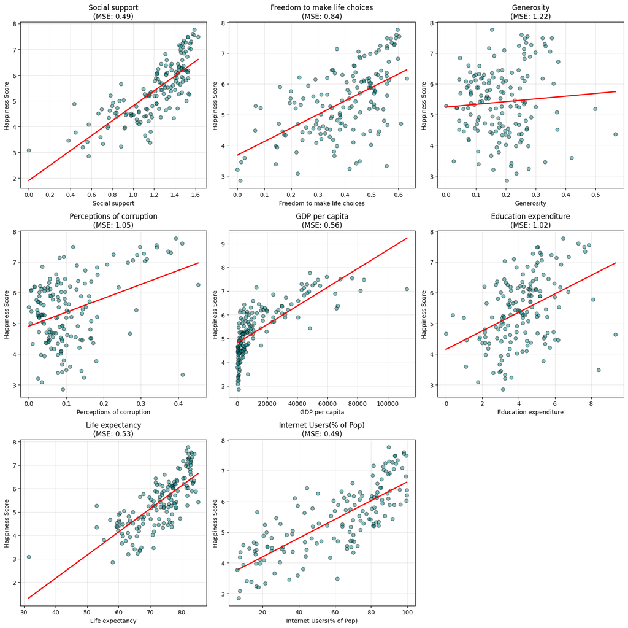

```python
# ==========================================
# Visualization. Correlation graphs for each feature
# ==========================================

cols_to_plot = features.drop(columns=['Happiness score']).columns     # Select relevant columns to plot
n_plots = len(cols_to_plot)

n_cols = 3                                                            # Dynamic Layout Calculation
n_rows = math.ceil(n_plots / n_cols)                                  # Calculate required rows (e.g., 7 plots -> 3 rows)

fig, axes = plt.subplots(nrows=n_rows, ncols=n_cols, figsize=(15, 5 * n_rows))  # Create the Grid
axes = axes.flatten()                                                 # Flatten 2D grid to 1D list

for i, col_name in enumerate(cols_to_plot):                           # Loop and Plot
    X_col = df[[col_name]].values
    y = df['Happiness score'].values

    model = LinearRegression()                                        # Fit model for this feature
    model.fit(X_col, y)
    y_pred = model.predict(X_col)
    mse = mean_squared_error(y, y_pred)

    ax = axes[i]                                                      # Plotting the axes
    ax.scatter(X_col, y, alpha=0.5, edgecolors='k', color='teal')

    x_line = np.linspace(X_col.min(), X_col.max(), 100).reshape(-1, 1)         # Regression Line
    ax.plot(x_line, model.predict(x_line), color='red', linewidth=2)

    # Labels
    ax.set_title(f"{col_name}\n(MSE: {mse:.2f})")
    ax.set_xlabel(col_name)
    ax.set_ylabel("Happiness Score")
    ax.grid(True, alpha=0.3)


# Remove empty subplots (clean up)
# For example, if you have 7 plots in a 3x3 grid (9 slots), this removes the last 2 empty ones
for j in range(i + 1, len(axes)):
    fig.delaxes(axes[j])

plt.tight_layout()
plt.show()
```

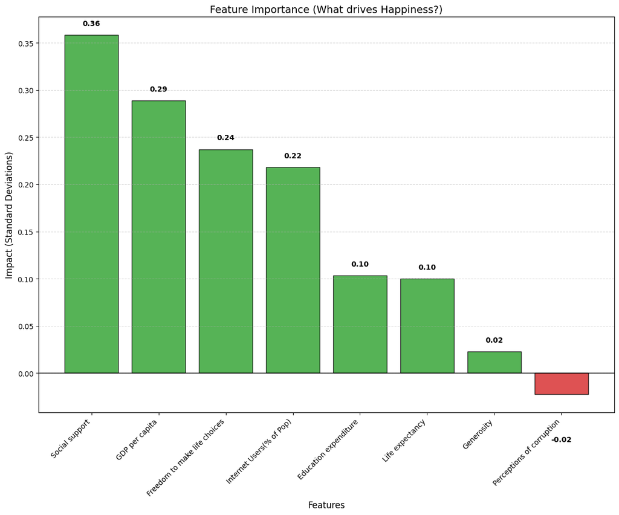

```python
# ==========================================
# Visualization. Histogram
# ==========================================
plt.figure(figsize=(12, 10))

# Color logic: Green for positive impact, Red for negative
colors = ['#2ca02c' if c > 0 else '#d62728' for c in coefficients['Coefficient']]

plt.bar(coefficients["Feature"], coefficients["Coefficient"], color=colors, edgecolor='black', alpha=0.8)
plt.axhline(0, color='black', linewidth=1)

plt.title("Feature Importance (What drives Happiness?)", fontsize=14)
plt.ylabel("Impact (Standard Deviations)", fontsize=12)
plt.xlabel("Features", fontsize=12)
plt.xticks(rotation=45, ha='right')
plt.grid(axis='y', linestyle='--', alpha=0.5)

# Add value labels on top of bars
for index, value in enumerate(coefficients['Coefficient']):
    plt.text(index, value + (0.01 if value > 0 else -0.05), f"{value:.2f}",
             ha='center', fontsize=10, fontweight='bold')

plt.tight_layout()
plt.show()
```

### Results of the Analysis

The standardized regression model achieved an **$R^2$ score of 0.640**, indicating that these features can explain roughly 64% of the variance in global happiness.

By ranking the standardized coefficients, we arrived at the following conclusions about what truly drives well-being:

1. **Community Over Capital:** The single most powerful predictor of a nation's happiness is **Social Support (0.358)**. This surpasses even economic factors, suggesting that a population's sense of having someone to rely on is the foundational bedrock of national well-being.
2. **The "Big Three" Pillars:** Following Social Support, the next most critical factors are **GDP per Capita (0.289)** and **Freedom to make life choices (0.237)**. Together with Social Support, these three variables form the primary tier of influence.
3. **The Digital Proxy:** **Internet Users (0.218)** remains a significant predictor. In this model, internet access likely acts as a strong proxy for a country's modern infrastructure and access to information, capturing development aspects that GDP alone might miss.
4. **Factors with Low Marginal Impact:** Once the major factors (Money, Community, Freedom) are accounted for, variables like **Generosity (0.022)** and **Perceptions of Corruption (-0.023)** have a surprisingly negligible impact on the final score. This implies that while corruption is negative, its effect is easily overshadowed by the presence of strong positive factors like social support.

## Clusters

To identify distinct "global tiers" of development, we applied an unsupervised machine learning technique called **K-Means Clustering**. Unlike the regression analysis, which predicts a specific score, clustering allows us to uncover natural groupings in the data based on shared characteristics.

### 1. Determination of Optimal Clusters ($K=3$)

Before running the final model, we utilized the **Elbow Method** to determine the optimal number of groups. By calculating the "Inertia" (sum of squared distances within clusters) for range $K=1$ to $K=10$, we observed a sharp "elbow" at **$K=3$**.

- **Interpretation:** This suggests that the world's nations naturally fall into three distinct categories (roughly corresponding to Underdeveloped, Developing, and Developed nations). Adding more clusters beyond 3 yields diminishing returns in model precision.

### 2. The Model

We trained the K-Means algorithm ($K=3$) on the standardized feature set.

### 3. Cluster Centroids (The "Average" Country)

The table below displays the **Centroids**—the mathematical center of each cluster. These values represent the "average profile" of a country belonging to that group.

[output not shown]

**Cluster Descriptions:**

- **Cluster 1 (The "Struggling" Nations):** Characterized by very low GDP (~$2k) and significant deficits in social support (0.93). These nations struggle to convert what little wealth they have into happiness.
- **Cluster 2 (The "Emerging" Middle):** This is the transition zone. With a GDP (~$14k) roughly **7x higher** than the bottom cluster, they achieve a massive jump in happiness (+1.5 points), showing the high marginal utility of income at this stage.
- **Cluster 0 (The "Thriving" Elite):** The wealthiest nations. Despite having **4x the GDP** of Cluster 2 (\$56k vs \$14k), the happiness gain is smaller (+1.2 points), illustrating the "diminishing returns" of extreme wealth.

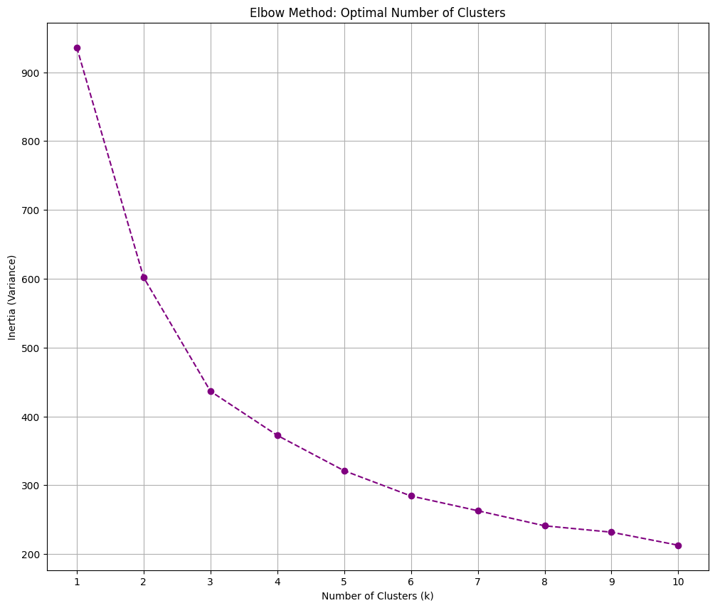

```python
# ==========================================
# Prepare Data for Clustering
# ==========================================
# We select the features that define a country's status + outcome
features_for_clustering = [
    'Happiness score',
    'GDP per capita',
    'Social support',
    'Freedom to make life choices',
    'Generosity',
    'Perceptions of corruption'
]

# Create the subset
X_cluster = df[features_for_clustering].copy()

# SCALE THE DATA (Crucial!)
scaler_cluster = StandardScaler()
X_cluster_scaled = scaler_cluster.fit_transform(X_cluster)

# ==========================================
# The Elbow Method Loop
# ==========================================
inertia = []
k_range = range(1, 11)

for k in k_range:
    kmeans = KMeans(n_clusters=k, random_state=42, n_init=10) # n_init suppresses warnings
    kmeans.fit(X_cluster_scaled)
    inertia.append(kmeans.inertia_)

# ==========================================
# Plotting the Elbow
# ==========================================
plt.figure(figsize=(12, 10))
plt.plot(k_range, inertia, marker='o', linestyle='--', color='purple')
plt.title('Elbow Method: Optimal Number of Clusters')
plt.xlabel('Number of Clusters (k)')
plt.ylabel('Inertia (Variance)')
plt.grid(True)
plt.xticks(k_range)
plt.show()
```

### Determination of Optimal Clusters ($K=3$)

To determine the most natural grouping of countries, we utilized the Elbow Method, which tracks the "Inertia" (sum of squared distances within clusters) as we increase the number of groups.

Why we chose $K=3$:

- The "Elbow" Point: As observed in the chart, the inertia drops dramatically when moving from 1 to 2 clusters, and again significantly from 2 to 3.
- Diminishing Returns: After $K=3$, the curve begins to flatten (or "bend"). Adding a 4th or 5th cluster yields only marginal improvements in model tightness while making the interpretation more complex.
- Interpretability: Statistically, $K=3$ represents the "sweet spot" where we maximize the distinction between groups without over-fragmenting the data. In the context of global development, this likely corresponds to three distinct tiers: Underdeveloped, Developing, and Highly Developed nations.

```python
# ==========================================
# 1. Setup & Clustering (Recap)
# ==========================================
# Ensure we have the clusters ready
features_for_clustering = [
    'Happiness score', 'GDP per capita', 'Social support',
    'Freedom to make life choices',
    'Generosity', 'Perceptions of corruption'
]

# Scale & Fit
X_cluster = df[features_for_clustering].copy()
scaler = StandardScaler()
X_cluster_scaled = scaler.fit_transform(X_cluster)

kmeans = KMeans(n_clusters=3, random_state=42, n_init=10)
df['Cluster'] = kmeans.fit_predict(X_cluster_scaled)

# ==========================================
# 2. Calculate Centroids for Plotting
# ==========================================
# Since we are plotting in 2D (GDP vs Happiness), the "Visual Centroid"
# is just the average of those two columns for each cluster.
centroids_2d = df.groupby('Cluster')[['GDP per capita', 'Happiness score']].mean()
```

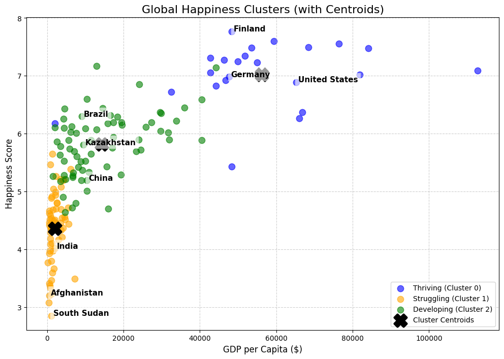

```python
# ==========================================
# 3. Visualization
# ==========================================
plt.figure(figsize=(12, 8))

# Define colors (adjust indices 0,1,2 to match your specific run if needed)
colors = ['blue', 'orange', 'green']
labels = ['Thriving (Cluster 0)', 'Struggling (Cluster 1)', 'Developing (Cluster 2)']

# A. Scatter the Countries
for cluster_id in range(3):
    cluster_data = df[df['Cluster'] == cluster_id]
    plt.scatter(
        cluster_data['GDP per capita'],
        cluster_data['Happiness score'],
        color=colors[cluster_id],
        alpha=0.6,
        s=80,
        label=labels[cluster_id]
    )

# B. Plot the Centroids (The "Center of Gravity")
plt.scatter(
    centroids_2d['GDP per capita'],
    centroids_2d['Happiness score'],
    color='black',
    marker='X',
    s=300, # Big size
    linewidths=3,
    label='Cluster Centroids'
)

# C. Label Specific Countries
countries_to_label = [
    'Finland', 'United States', 'South Sudan',
    'China', 'India', 'Kazakhstan',
    'Germany', 'Brazil', 'Afghanistan'
]

for country in countries_to_label:
    row = df[df['Country'] == country]
    if not row.empty:
        plt.text(
            x=row['GDP per capita'].iloc[0] + 500, # Slight offset
            y=row['Happiness score'].iloc[0],
            s=country,
            fontsize=11,
            weight='bold',
            bbox=dict(facecolor='white', alpha=0.6, edgecolor='none')
        )

# Styling
plt.title('Global Happiness Clusters (with Centroids)', fontsize=16)
plt.xlabel('GDP per Capita ($)', fontsize=12)
plt.ylabel('Happiness Score', fontsize=12)
plt.legend(loc='lower right')
plt.grid(True, linestyle='--', alpha=0.6)

plt.show()
```

```python
# ==========================================
# Interpret the Clusters (The "Stats" Table)
# ==========================================
# We group by the cluster label and calculate the mean of key features
cluster_summary = df.groupby('Cluster')[features_for_clustering].mean()
print("\nCluster Profiles (Average Values):")
cluster_summary
```

```
Cluster Profiles (Average Values):
```

| Cluster | Happiness score | GDP per capita | Social support | Freedom to make life choices | Generosity | Perceptions of corruption |
| --- | --- | --- | --- | --- | --- | --- |
| 0 | 7.023609 | 56209.666629 | 1.494913 | 0.547870 | 0.274870 | 0.281174 |
| 1 | 4.362508 | 2066.843761 | 0.927143 | 0.324492 | 0.204365 | 0.094746 |
| 2 | 5.816086 | 14286.891007 | 1.368314 | 0.402814 | 0.137700 | 0.068829 |

```python
# ==========================================
# 4. Generate Samples (Printed Separately)
# ==========================================
print("\n--- Representative Countries by Cluster ---")

# Loop through each cluster (0, 1, 2)
for cluster_id in range(3):
    print(f"\n[ Cluster {cluster_id} Samples ]")

    # Get 3 random countries from this specific cluster
    samples = df[df['Cluster'] == cluster_id].sample(3, random_state=42)

    # Print just the relevant columns
    print(samples[['Country', 'GDP per capita', 'Happiness score']].to_string(index=False))
```

```
--- Representative Countries by Cluster ---

[ Cluster 0 Samples ]
Country  GDP per capita  Happiness score
Belgium    46716.622747            6.923
Austria    49885.994736            7.246
Finland    48358.180777            7.769

[ Cluster 1 Samples ]
                 Country  GDP per capita  Happiness score
Central African Republic      449.228468            3.083
             Yemen, Rep.      633.890000            3.380
                Pakistan     1390.416910            5.653

[ Cluster 2 Samples ]
   Country  GDP per capita  Happiness score
 Nicaragua     1958.620515            6.105
Costa Rica    12884.685995            7.167
Montenegro     8842.485287            5.523
```

### Results for the Clustering Analysis

Using K-Means clustering ($K=3$), the algorithm successfully segmented the dataset into three distinct global tiers. The visualization reveals a clear trajectory of development, with countries grouped not just by geography, but by shared socioeconomic realities.

#### 1. Cluster 1: The "Struggling" Nations (Orange)

- Profile: Low Income (roughly $2,066 avg GDP) & Low Happiness (roughly 4.36 avg Score).
- Description: This cluster represents the most vulnerable nations. The data shows that these countries face a "double burden" of extremely low economic output and significantly lower Social Support (0.92) compared to the other groups.
- Representative Countries: South Sudan, Afghanistan, Yemen, Central African Republic, and Pakistan.
- Visual Location: Bottom-left corner of the chart, showing a dense concentration of countries struggling to break past the $5,000 GDP mark.

#### 2. Cluster 2: The "Emerging" Middle (Green)

- Profile: Middle Income (roughly $14,286 avg GDP) & Moderate Happiness (roughly 5.81 avg Score).
- Description: This is the "transition" zone. Interestingly, while their average GDP is roughly 7x higher than the Struggling cluster, their Happiness Score jumps significantly by roughly 1.5 points. This group includes rapidly developing economies that have secured basic stability but have not yet reached elite wealth status.
- Representative Countries: Brazil, China, Kazakhstan, Costa Rica, and Montenegro.
- Visual Location: The steep "curve" of the graph. This cluster demonstrates the highest "marginal return" on wealth—small increases in GDP here lead to massive gains in happiness.

#### 3. Cluster 0: The "Thriving" Elite (Blue)

- Profile: High Income (roughly $56,209 avg GDP) & High Happiness (roughly 7.02 avg Score).
- Description: These nations score highest across every metric. However, the "diminishing returns" phenomenon is most visible here. Despite having 4x the GDP of the Emerging cluster ($56k vs $14k), their happiness score is only roughly 1.2 points higher. This suggests that beyond a certain threshold, extra wealth yields smaller improvements in well-being.
- Representative Countries: Finland, United States, Germany, Austria, and Belgium.
- Visual Location: The top-right plateau, where the curve flattens out.

#### 4. Observations on Outliers (The "Happy Poor")

While the general trend indicates that higher GDP correlates with happiness, the clustering reveals important outliers that challenge this rule.

- "Punching Above Their Weight": Some nations, such as Nicaragua, were assigned to the "Emerging" (Green) cluster despite having a GDP (roughly $1,958) that is typical of the "Struggling" (Orange) cluster.
- Analysis: Nicaragua's high Happiness Score (6.105) allows it to defy its economic category. This suggests that for certain nations, strong performance in non-monetary metrics—such as Social Support or Freedom—can effectively compensate for lower economic output, allowing the population to achieve high well-being without high wealth.

# Conclusion & Evaluation

## 1. Synthesis of Findings

This project set out to decode the primary drivers of global well-being by analyzing data from 156 nations. By integrating statistical profiles, regression modeling, and unsupervised clustering, we have derived the following insights:

### A. The Global Landscape (Descriptive Statistics)

The world shows a moderate level of happiness with a global mean of **5.41** ($\sigma=1.11$). However, this average hides extreme disparities.

- **The Ceiling:** Nordic nations, led by **Finland (7.77)**, **Denmark**, and **Norway**, consistently set the benchmark for high well-being.
- **The Floor:** Conflict-affected nations such as **South Sudan (2.85)** and the **Central African Republic** represent the lower bound, highlighting how instability devastates national mood.

### B. The Economics of Happiness (Regression Analysis)

Through polynomial and logarithmic regression testing, we confirmed that the relationship between wealth (GDP) and happiness is **non-linear**.

### C. The Pillars of Well-Being (Feature Significance)

Using **Standardized Multivariate Regression**, we isolated the impact of specific features independent of their scale. The model achieved an **$R^2$ of 0.640**, explaining nearly two-thirds of the variance in global scores.

- **Primary Driver:** Surprisingly, **Social Support (0.358)** outperformed **GDP per capita (0.289)** as the strongest predictor of happiness.
- **Secondary Driver:** **Freedom to make life choices (0.237)** and **Internet Access (0.218)** proved to be critical secondary pillars.
- **Insignificance:** Contrary to expectations, **Generosity** and **Perceptions of Corruption** showed negligible direct impact on the overall score in this specific model.

### D. Distinct Global Tiers (Clustering)

Using the **Elbow Method**, we determined that the world naturally segments into **$K=3$** distinct clusters.

1. **Cluster 1 (Struggling):** Low GDP (~\$2k) and low social support.
2. **Cluster 2 (Emerging):** The "transition zone" where happiness rises sharply with moderate economic gains (~\$14k GDP).
3. **Cluster 0 (Thriving):** The wealthy plateau (~\$56k GDP) where happiness scores stabilize near 7.0.

## 2. Evaluation & Limitations

While our analysis provides robust insights, the following limitations must be considered regarding the methodology and data integrity.

### Data Processing & Imputation

- **Imputation Bias:** To maintain a dataset of 156 countries, we utilized **KNN (K-Nearest Neighbors) imputation** to estimate missing values for "Education Expenditure." While this prevents data loss, it introduces synthetic data based on mathematical similarity rather than observed reality.
- **Label Inconsistencies:** Significant effort was required to harmonize inconsistent country labels (e.g., "Congo (Kinshasa)" vs. "DRC"). While corrected, any remaining mismatches could exclude micro-states from the final merge.

### Methodological Constraints

- **Correlation $\neq$ Causation:** Our regression proves that Happiness and GDP move together, but it does not prove directionality. It is plausible that happier populations are more productive, creating a reverse causality loop.
- **Omitted Variable Bias:** With an $R^2$ of 0.64, roughly **36% of the variance** remains unexplained. Factors such as climate, political stability, mental health infrastructure, and cultural values (which are difficult to quantify) are missing from the model.

### Metric Subjectivity

- **Self-Reporting Bias:** The "Happiness Score" is subjective (Cantril Ladder). Cultural norms heavily influence these ratings; in some cultures, reporting extreme happiness is frowned upon, while in others, it is socially expected. This introduces a "cultural noise" that standardizing data cannot fully remove.